# Take Home Final

Gabe Mancino

4/25/2018

**This is a take-home exam, and is to be completed on your own. Any evidence of collaboration will result in severe penalization for all collaborators. Submit your responses in a Word or pdf document compiled by R Markdown, along with your .Rmd source, to D2L by 11:59 pm on May 3, 2018.**

1. (30 points) (Modified from Dr. Bergen’s MS qualifying exam, June 2010.) Consider the simple linear regression problem:

$$Y_i = \beta_0 + \beta_1 x_i + \epsilon_i, i=1,...,n$$

The $x_i$ are fixed and known and are mean-centered, implying that $\sum_{i=1}^n x_i = 0$. The error terms $\epsilon_i\stackrel{iid}{\sim} N(0,\sigma^2)$ with known $\sigma^2$. (Note that all of this is equivalent to saying $Y_i\stackrel{iid}{\sim} N(\beta_0 + \beta_1x_i,\sigma^2)$). The regression parameters $\beta_0$ and $\beta_1$ are unknown, and the target of inference is $\theta = \beta_1^2$.

1. (5 points) Find $\hat\theta_{MLE}$.

**Solution.**

Since MLE’s are invariant, finding $\hat{\beta}_{1,MLE}$ and squaring this will give $\hat{\theta}_{MLE},$ so begin by simplifying $L(\beta_1)$:

$$L(\beta_1)=\prod_{i=1}^{n}\Big(\frac{1}{2\pi\sigma^2}\Big)^{1/2}e^{\frac{1}{2\sigma^2}(y_i-(\beta_0+\beta_1x_i))^2}=\Big(\frac{1}{2\pi\sigma^2}\Big)^{n/2}e^{\frac{1}{2\sigma^2}\sum(y_i-(\beta_0+\beta_1x_i))^2}.$$

Focus on the exponent by foiling:

$$\frac{1}{2\sigma^2}\sum(y_i-(\beta_0+\beta_1x_i))^2=\frac{1}{2\sigma^2}\sum(\beta_0^2+2\beta_0\beta_1x_i+\beta_1^2x_i^2-2\beta_0y_i-2\beta_1x_iy_i+y_i^2).$$

Now taking the natural log yields:

$$\begin{aligned}
\ln L(\beta_1)&=-\frac{n}{2}\ln(2\pi\sigma^2)-\frac{1}{2\sigma^2}\sum(\beta_0^2+2\beta_0\beta_1x_i+\beta_1^2x_i^2-2\beta_0y_i-2\beta_1x_iy_i+y_i^2)\\
&=-\frac{n}{2}\ln(2\pi\sigma^2)-\frac{1}{2\sigma^2}(n\beta_0^2+\beta_0\beta_1\sum x_i+\beta_1^2\sum x_i^2-2\beta_0\sum y_i-2\beta_1\sum x_iy_i+\sum y_i^2).
\end{aligned}$$

Taking the derivative with respect to $\beta_1$ gives:

$$\frac{\partial}{\partial\beta_1}\ln L(\beta_1)=\frac{\sum x_iy_i}{\sigma^2}-\frac{\beta_1\sum x_i^2}{\sigma^2}\stackrel{set}{=}0.$$

Thus $\hat{\beta}_1=\frac{\sum y_ix_i}{\sum x_i^2}$ and since MLE’s are invariant,

$$\hat{\theta}_{MLE}=\Big(\frac{\sum y_ix_i}{\sum x_i^2}\Big)^2.$$

B. (5 points) Find the bias of $\hat\theta_{MLE}$ for estimating $\theta$.

**Solution.**

First, note that $E[\Big(\frac{\sum y_ix_i}{\sum x_i^2}\Big)^2]=\frac{1}{(\sum x_i^2)^2}E[(\sum y_ix_i)^2].$ Now, we make use of the fact that $E[X^2]=Var[X]-E[X]^2.$ First, computing $E[\sum y_ix_i]=x_1(\beta_0+\beta_1x_1)+x_2(\beta_0+\beta_1x_2)+\dots+x_n(\beta_0+\beta_1x_n)=\beta_0\sum x_i+\beta_1\sum x_i^2=\beta_1\sum x_i^2.$ Squaring this yields $E[\sum x_iy_i]^2=\beta_1^2(\sum x_i^2)^2.$ Second, computing $Var[\sum y_ix_i]=\sum x_i^2Var(y_i)$ (notice the covariances are zero since $y_i$ is independent from $y_j$ for $i\ne j$), then, $Var[y_i]=\sigma^2$ for all $y_i$ so $Var[\sum y_ix_i]=\sigma^2\sum x_i^2.$ Combining the above information:
$$\frac{1}{(\sum x_i^2)^2}E[(\sum y_ix_i)^2]=\frac{1}{(\sum x_i^2)^2}\Big(\sigma^2\sum x_i^2+\beta_1^2(\sum x_i^2)^2\Big)=\frac{\sigma^2}{\sum x_i^2}+\beta_1^2.$$
Thus the bias of $\hat{\theta}_{MLE}$ is $\frac{\sigma^2}{\sum x_i^2}.$

C. (5 points) Derive a crude lower bound for the variance of $\hat\theta_{MLE}$ by treating $\beta_0$ as known.

**Solution.**

Using the definition of the Cramer-Rao Lower Bound and the fact that $Var(Y+b)=Var(Y)$ for all constants $b$, define $\tau(\theta):=\beta_1^2+\frac{\sigma^2}{\sum x_i^2},$ then $\hat{\theta}_{MLE}$ is unbiased for $\hat{\tau}(\theta).$ Thus,

$$Var(\hat{\theta}_{MLE})=Var(\hat{\tau}(\theta))\ge\frac{\tau'(\theta)^2}{-nE[\frac{\partial^2}{\partial\beta_1^2}\ln L(y;\beta_1)]}$$

Computing $\tau'(\theta)=2\beta_1$ and $I(\beta_1)=\frac{n\sum x_i^2}{\sigma^2}$ we find that a lower bound on the variance of $\hat{\theta}_{MLE}$ is $\frac{4\beta_1^2\sigma^2}{n\sum x_i^2}$ where in practice $\beta_1$ would need to be estimated.

D. (3 points) Derive an unbiased estimator for $\theta$ by a simple modification to $\hat\theta_{MLE}$ (call it $\hat\theta_{UB}$).

**Solution.**

Simply subtract $\frac{\sigma^2}{\sum x_i^2}$ from $\hat{\theta}_{MLE}$ to receive

$$\hat{\theta}_{UB}=\hat{\theta}_{MLE}-\frac{\sigma^2}{\sum x_i^2}.$$

E. (3 points) Identify a shortcoming of $\hat\theta_{UB}$ and suggest an improvement. Let $\hat\theta_{IMP}$ notate your suggested improvement.

**Solution.**

Notice that if $\sigma^2$ is large (or $\sum x_i^2$ is sufficiently small) then $\hat{\theta}_{UB}<0.$ This is bad since the quantity $\theta$ is estimating is $\beta_1^2\in[0,\infty).$ So defining

$$\hat{\theta}_{IMP}=
\begin{cases}
0&\quad\text{if}\quad \frac{\sigma^2}{\sum x_i^2}>\hat{\theta}_{MLE}\\
\hat{\theta}_{UB}&\quad\text{otherwise}
\end{cases}$$
will be an improved estimator.

F. (9 points) Let $\beta_0 = 0$ and $\sigma^2 = 1$. Given $n$, suppose there are $n/5$ $x_i$ each at $\{-2,-1,0,1,2\}$. Consider all 6 combinations of $n \in \{10, 20, 100\}$ and $\beta_1 \in \{0.5,2\}.$ Carry out a simulation study to compare the MSE of your three estimators $\hat\theta_{MLE},$ $\hat\theta_{UB}$, and $\hat\theta_{IMP}$. Summarize your simulation results in a table. Full credit will only be given if your results are rounded to a reasonable number of digits. Comment on which estimator is best.

**Solution.**

Consider the following code and tables.

```r
# Function for computing Thetas for Beta_1 = 0.5
theta.hats.0.5 <- function(n) {
  xi <- c(-2, -1, 0, 1, 2)
  samp <- c()
  for (i in 1:5){
      samp <- c(samp, rnorm(n / 5, mean = 0.5 * xi[i], sd = 1))
  }
  xi <- rep(xi, each = n / 5)
  num <- c()
  for (i in 1:n){
    num[i] <- samp[i] * xi[i]
  }
  theta.mle <- (sum(num) / sum(xi^2)) ^ 2
  theta.ub <- theta.mle - (1 / sum(xi^2))
  theta.imp <- ifelse((1/sum(xi^2)) > theta.mle, 0, theta.ub)
  return(c(Theta.MLE = theta.mle, Theta.UB = theta.ub, Theta.IMP = theta.imp))
}
# MSE function for Beta_1 = 0.5
mse.0.5 <- function(estimator){
  bias <- mean(estimator) - 0.5^2
  var <- var(estimator)
  mse <- var + (bias)^2
  return(mse)
}
# Replication and Data Frames for Beta_1 = 0.5
r <- 10000
many.thetahats.0.5_n10 <- replicate(r, theta.hats.0.5(10))
many.thetahats.0.5_n20 <- replicate(r, theta.hats.0.5(20))
many.thetahats.0.5_n100 <- replicate(r, theta.hats.0.5(100))
df.mse.0.5.10 <- round(data.frame(MSE.Theta_MLE = mse.0.5(many.thetahats.0.5_n10[1,]), MSE.Theta_UB = mse.0.5(many.thetahats.0.5_n10[2,]), MSE.Theta.IMP = mse.0.5(many.thetahats.0.5_n10[3,])), digits = 3)
df.mse.0.5.20 <- round(data.frame(MSE.Theta_MLE = mse.0.5(many.thetahats.0.5_n20[1,]), MSE.Theta_UB = mse.0.5(many.thetahats.0.5_n20[2,]), MSE.Theta.IMP = mse.0.5(many.thetahats.0.5_n20[3,])), digits = 3)
df.mse.0.5.100 <- round(data.frame(MSE.Theta_MLE = mse.0.5(many.thetahats.0.5_n100[1,]), MSE.Theta_UB = mse.0.5(many.thetahats.0.5_n100[2,]), MSE.Theta.IMP = mse.0.5(many.thetahats.0.5_n100[3,])), digits = 3)

# Function for computing Thetas for Beta_1 = 2
theta.hats.2 <- function(n) {
  xi <- c(-2, -1, 0, 1, 2)
  samp <- c()
  for (i in 1:5){
    samp <- c(samp, rnorm(n / 5, mean = 2 * xi[i], sd = 1))
  }
  xi <- rep(xi, each = n / 5)
  num <- c()
  for (i in 1:n){
    num[i] <- samp[i] * xi[i]
  }
  theta.mle <- (sum(num) / sum(xi^2)) ^ 2
  theta.ub <- theta.mle - (1 / sum(xi^2))
  theta.imp <- ifelse((1/sum(xi^2)) > theta.mle, 0, theta.ub)
  return(c(Theta.MLE = theta.mle, Theta.UB = theta.ub, Theta.IMP = theta.imp))
}
# MSE function for Beta_1 = 2
mse.2 <- function(estimator){
  bias <- mean(estimator) - 2^2
  var <- var(estimator)
  mse <- var + (bias)^2
  return(mse)
}
# Replication and Data Frames for Beta_1 = 2
many.thetahats.2_n10 <- replicate(r, theta.hats.2(10))
many.thetahats.2_n20 <- replicate(r, theta.hats.2(20))
many.thetahats.2_n100 <- replicate(r, theta.hats.2(100))
df.mse.2.10 <- round(data.frame(MSE.Theta_MLE = mse.2(many.thetahats.2_n10[1,]), MSE.Theta_UB = mse.2(many.thetahats.2_n10[2,]), MSE.Theta.IMP = mse.2(many.thetahats.2_n10[3,])), digits = 3)
df.mse.2.20 <- round(data.frame(MSE.Theta_MLE = mse.2(many.thetahats.2_n20[1,]), MSE.Theta_UB = mse.2(many.thetahats.2_n20[2,]), MSE.Theta.IMP = mse.2(many.thetahats.2_n20[3,])), digits = 3)
df.mse.2.100 <- round(data.frame(MSE.Theta_MLE = mse.2(many.thetahats.2_n100[1,]), MSE.Theta_UB = mse.2(many.thetahats.2_n100[2,]), MSE.Theta.IMP = mse.2(many.thetahats.2_n100[3,])), digits = 3)
```

| $\beta_1=0.5$ | $n=10$ | $n=20$ | $n=100$ |
| --- | --- | --- | --- |
| $MSE(\hat{\theta}_{MLE})$ | 0.058 | 0.026 | 0.005 |
| $MSE(\hat{\theta}_{UB})$ | 0.056 | 0.026 | 0.005 |
| $MSE(\hat{\theta}_{IMP})$ | 0.054 | 0.026 | 0.005 |

| $\beta_1=2$ | $n=10$ | $n=20$ | $n=100$ |
| --- | --- | --- | --- |
| $MSE(\hat{\theta}_{MLE})$ | 0.802 | 0.405 | 0.081 |
| $MSE(\hat{\theta}_{UB})$ | 0.799 | 0.405 | 0.081 |
| $MSE(\hat{\theta}_{IMP})$ | 0.799 | 0.405 | 0.081 |

By the above tables, we find that $\hat{\theta}_{IMP}$ is the best estimator with respect to minimizing MSE.

2. (35 points) (Modified from Gelman et al *Bayesian Data Analysis* 3ed, p 45). Suppose that causes of death are reviewed in detail for a city of size 200,000 in the United States for a single year. Let $Y$ represent the number of persons, out of a population of 200,000, that died of asthma within a year. A Poisson model is often used for epidemiological data of this form; specifically, $Y\sim POI(2\theta)$, where $\theta$ represents the true rate of deaths from asthma, per 100,000 population. Suppose that within the year, $Y=3$.
1. (2 points) What is $\hat\theta_{MLE}$?

**Solution.**

To find $\hat{\theta}_{MLE},$ maximize $L(\theta)=\prod\limits_{i=1}^{n}e^{-2\theta}\frac{2\theta^{y_i}}{y_i!}=e^{-2n\theta}\frac{(2\theta)^{\sum y_i}}{\prod y_i!}$ with respect to $\theta$:
$$\ln L(\theta)=-2n\theta+\sum y_i\ln(2\theta)-\ln(\prod y_i!).$$
Taking the derivate and setting it equal to zero yields:
$$\frac{d}{d\theta}\ln L(\theta)=-2n+2\frac{\sum y_i}{2\theta}\stackrel{set}{=}0\quad\Rightarrow\quad \hat{\theta}_{MLE}=\frac{\bar{Y}}{2}.$$

2. (3 points) Suppose reviews of asthma mortality rates around the world are rare in Western countries, with typical asthma mortality rates around 0.6 per 100,000. To account for this, we assume $\theta$ follows a prior distribution with $\theta \sim Gamma(\alpha,\beta)$. Suppose we also want to set the posterior $Var(\theta) = 0.12$. To what should the prior parameters $\alpha$ and $\beta$ be set to reflect this information?

**Solution.**

Denote “typical” to mean “on average” (i.e. the mean). Thus $E(\theta)=\alpha\beta=0.6$ and $Var(\theta)=\alpha\beta^2=0.12.$ Combining this information yields $\alpha = 3$ and $\beta=0.2.$

3. (3 points) Write down the function $q(\theta|Y = 3) = L(\theta) \times \pi(\theta)$.

**Solution.**

By straight froward multiplication, we obtain:

$$L(\theta)\pi(\theta)=e^{-2n\theta}\frac{(2\theta)^{\sum y_i}}{\prod y_i!}\frac{1}{\Gamma(\alpha)\beta^{\alpha}}\theta^{\alpha-1}e^{-\theta/\beta}.$$
Some simplification yields:
$$L(\theta)\pi(\theta)=\frac{2^{\sum y_i}}{\Gamma(\alpha)\beta^{\alpha}\prod y_i!}\theta^{\sum y_i+\alpha-1}e^{-\theta(2n+\frac{1}{\beta})}.$$

It is worth noting that the posterior is distributed $GAM(\sum y_i+\alpha,\frac{1}{2n+1/\beta}).$

4. (5 points) Suppose you are going to use rejection sampling to simulate 10,000 i.i.d. observations from $q$, using the prior distribution of your proposal function. To what should $M$ be set in the acceptance probability?

**Solution.**

We should set $M=L(\hat{\theta}_{MLE})$ (by our notes). Here, $\hat{\theta}_{MLE}=\bar{Y}/2=(3/1)/2=\frac{3}{2}.$ Thus $L(3/2)=$ 0.2240418 $\stackrel{set}{=}M$.

5. (10 points) Take a sample of size 10,000 from the posterior using rejection sampling. Include in your submission:
1. A histogram of your sample;
2. The posterior mean;
3. A 95% credible interval.

**Solution.** Consider the following code.

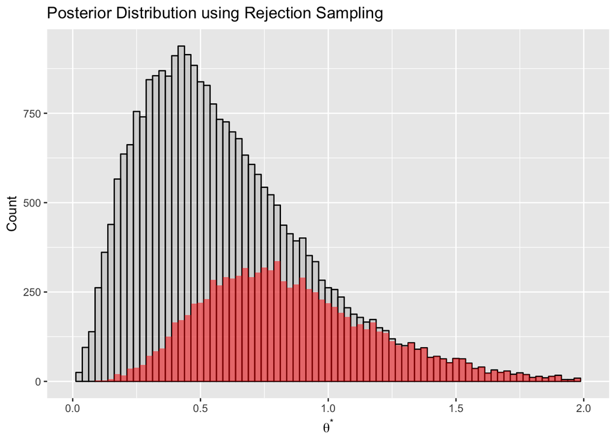

```r
set.seed(8495)
library(ggplot2)
library(dplyr)
M <- dpois(3, lambda = 2*(3/2)) # Liklihood evaluated at thetahat_MLE
post.samplesize <- 10000
all.thetastars <- c()
all.decisions <- c()
count <- 1
while(count <= post.samplesize){
  thetastar <- rgamma(1, shape = 3, scale = 0.2) # Generate 1 proposal
  accept.prob <- dpois(3, lambda = 2 * thetastar) / M
  new.decision <- rbinom(1, 1, accept.prob)
  all.thetastars <- c(all.thetastars, thetastar)
  all.decisions <- c(all.decisions, new.decision)
  count <- ifelse(new.decision == 1, count + 1, count)
}
df <- data.frame(all.thetastars, all.decisions)
posterior.sample <- df%>%filter(all.decisions == 1)
# Answer to i:
ggplot() +
  geom_histogram(data = df, aes(x = all.thetastars), binwidth = 0.025, alpha = 0.5, fill = 'grey', color = 'black') +
  geom_histogram(data = posterior.sample, aes(x = all.thetastars), binwidth = 0.025, alpha = 0.5, fill = 'red') + xlab(expression(theta^"*")) + ylab('Count') + ggtitle('Posterior Distribution using Rejection Sampling') + xlim(c(0, 2))
```

```r
# Answer to ii:
mean(posterior.sample$all.thetastars)
```

```
## [1] 0.86124
```

```r
# Answer to iii:
quantile(posterior.sample$all.thetastars, c(0.025, 0.975))
```

```
##      2.5%     97.5%
## 0.3137624 1.6766739
```

F. (12 points) Now use the Metropolis algorithm to generate 10,000 i.i.d. observations from the posterior. (Note that 10,000 is the number of final i.i.d. observations, *not* the entire length of the chain, which will probably be much longer!) For full credit, you should:

1. Discuss whether you discarded a burn-in period, and if so, how many observations you discarded (including relevant visualizations to support your decisions);
2. Describe to what extent you thinned your Markov Chain (again using relevant visualizations to support your decisions);
3. Create histogram, and find the posterior mean and 95% credible interval of your final (thinned, burn-in-discarded) sample.

**Solution.**

Consider the following code.

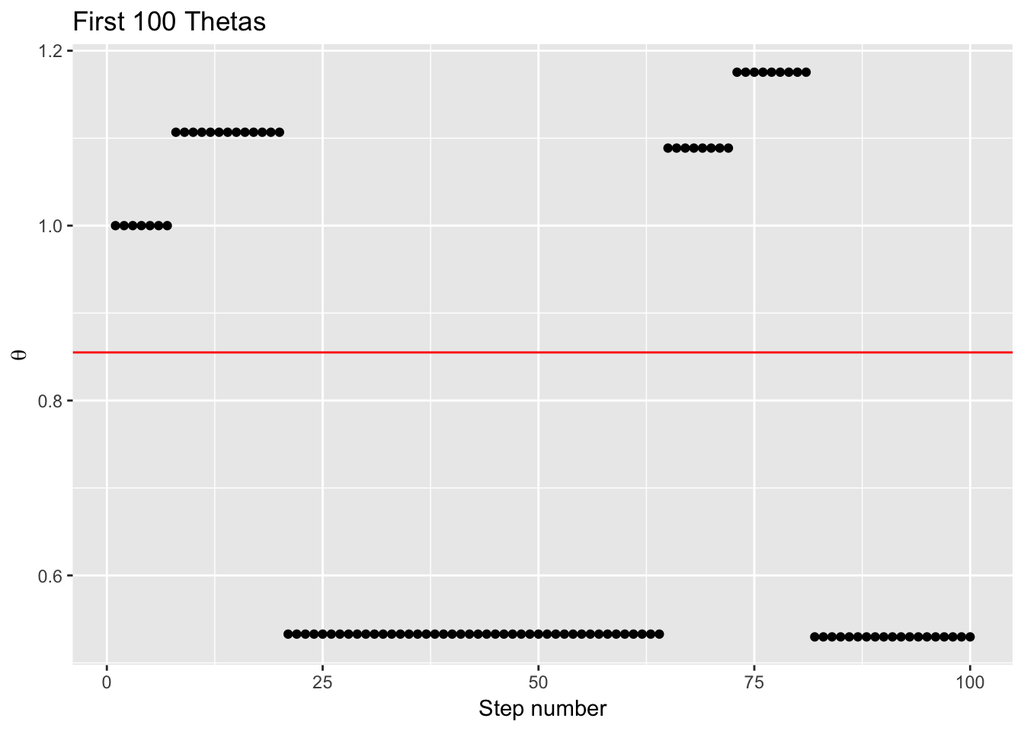

```r
q.theta <- function(theta){
    q <- ifelse(theta <= 0, 0, dpois(3, lambda = 2 * theta) * dgamma(theta, shape = 3, scale = 0.2))
  return(q)
}
post.samplesize <- 10000
thetas <- c()
thetas[1] <- 1
for(i in 2:post.samplesize){
  thetastar <- rnorm(1, mean = 0, sd = 10) # Proposal is NORMAL
  r <- q.theta(thetastar) / q.theta(thetas[i - 1])
  U <- runif(1)
  thetas[i] <- ifelse(U < r, thetastar, thetas[i - 1])
}
df <- data.frame(Step = 1:post.samplesize, theta = thetas)
ggplot(data = df[1:100,]) + geom_point(aes(x = Step, y = theta)) + ylab(expression(theta)) + xlab('Step number') + geom_hline(aes(yintercept = 0.855), col = 'red') + ggtitle('First 100 Thetas')
```

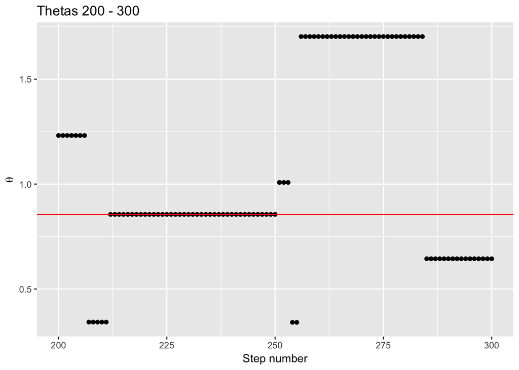

```r
ggplot(data = df[200:300,]) + geom_point(aes(x = Step, y = theta)) + ylab(expression(theta)) + xlab('Step number') + geom_hline(aes(yintercept = 0.855), col = 'red')+ ggtitle('Thetas 200 - 300')
```

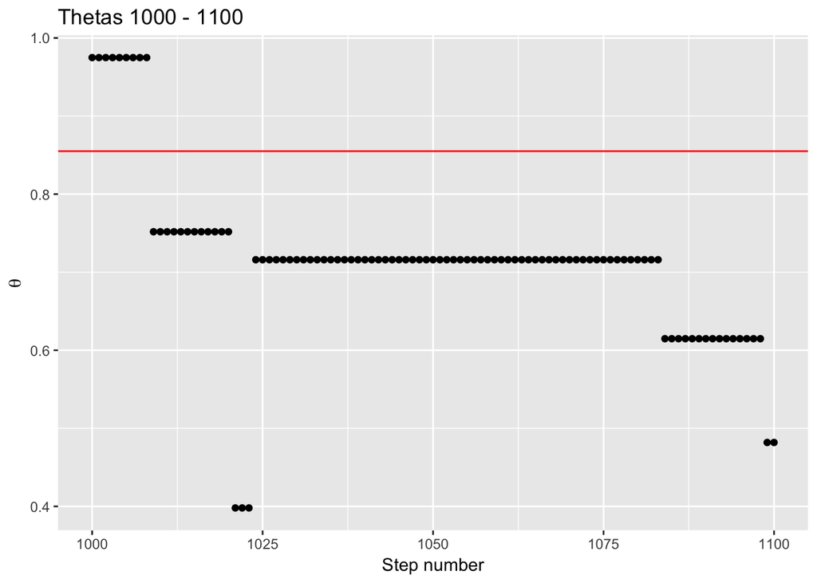

```r
ggplot(data = df[1000:1100,]) + geom_point(aes(x = Step, y = theta)) + ylab(expression(theta)) + xlab('Step number') + geom_hline(aes(yintercept = 0.855), col = 'red') + ggtitle('Thetas 1000 - 1100')
```

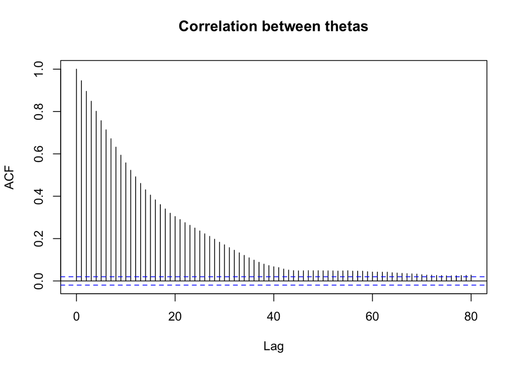

```r
acf(df$theta, lag.max = 80, xlab = "Lag", ylab = "ACF", main = "Correlation between thetas")
```

Using the above plots, we find it ideal to discard the first 1100 observations from the data set and only use every 80th realization; this will eliminate the “burn-in” period and also thin the Markov chain. Thus, the following code will create the desired posterior distribution.

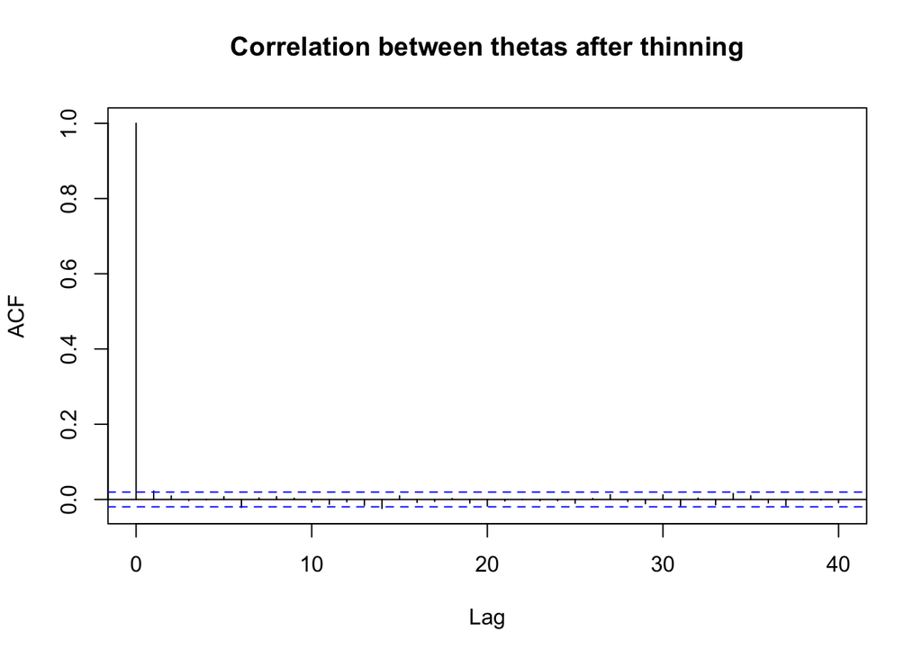

```r
new.post.sampsize <- 801100
thetas <- c()
thetas[1] <- 1
for(i in 2:new.post.sampsize){
  thetastar <- rnorm(1, mean = 0, sd = 10)
  r <- q.theta(thetastar) / q.theta(thetas[i - 1])
  U <- runif(1)
  thetas[i] <- ifelse(U < r, thetastar, thetas[i - 1])
}
df <- data.frame(Step = 1:new.post.sampsize, theta = thetas)
df.burn <- df[-(1:1100),]
df.thin <- df.burn[seq(1, nrow(df.burn), by = 80),]
acf(df.thin$theta, xlab = "Lag", ylab = "ACF", main = "Correlation between thetas after thinning")
```

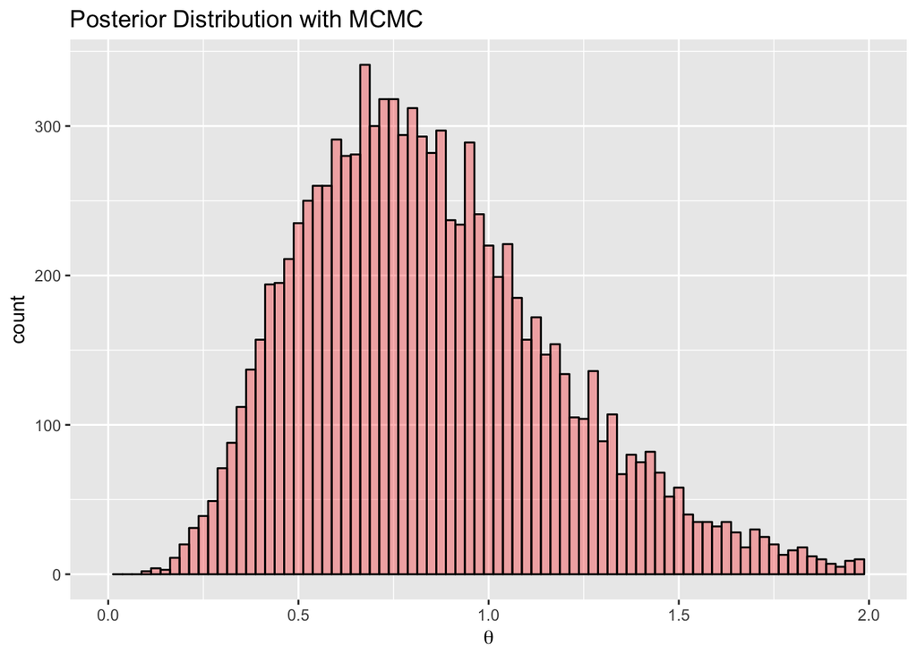

```r
ggplot(data = df.thin) + geom_histogram(aes(x = theta), binwidth = 0.025, alpha = 0.3, fill = 'red', col = 'black') + ggtitle('Posterior Distribution with MCMC') + xlab(expression(theta)) + xlim(c(0, 2))
```

```r
mean(df.thin$theta)
```

```
## [1] 0.8544099
```

```r
quantile(df.thin$theta, c(0.025, 0.975))
```

```
##      2.5%     97.5%
## 0.3172745 1.6588628
```

Thus we can see by both rejection sampling and MCMC methods, $\hat{\theta}_{BAYES}\approx0.85.$